# Mixed models - flower color and treatmenr

This script conducts analyses to test the effect of treatment (control, early drought and late drought) and color or phenotype (A.m. pseudomajus, F1 hybrids, and A.m. striatum) on individual trait responses.

Load packages

```r
## load required packages
pkgs <- c("lme4",

          "multcomp",

          "lsmeans",
          "tidyverse",

          "tidyverse",
          "dplyr",
          #"effsize",
          #"hrbrthemes",
          "viridis",
          #"plyr",
         # "cowplot",
         # "aods3",
         # "AER",
         # "pscl",
          "DHARMa",
         # "plotly",
          "ggpubr",
         # "extrafont",
          "car",
          "rcompanion",
         # "agricolae",
        #  "jtools",
        #  "sjPlot",
         # "VGAM",
         # "pracma",
        #  "rgl",
          "MASS",
         # "performance",
         # "brms",
        #  "sjstats",
        #  "sjmisc",
         #"lmerTest",
         #"rockchalk",
          "emmeans",
         #"afex",
         #"effects",
         "forcats",
      #    "visreg",
      #  "rstatix",
         #"lmerTest",
          #"ggstance",
         #"broomExtra",
     # "grid",
         "glmmTMB",
      #   "ggeffects",
         "patchwork"
     )


lapply(pkgs, library, character.only = TRUE)
rm(pkgs)
```

### Read data

the dataset used for the analyses is computed in **“compute_df_analyses.Rmd”**.

```r
Dataset <- read.csv("../dataset.csv")

# Filter to conduct analysis only for individuals resulted from between population crosses (discard within pop crosses)

Dataset <- Dataset %>%
  filter(w_b == "b")

# Set random effects as factors

Dataset$block <- as.factor(Dataset$block)
Dataset$cross <- as.factor(Dataset$cross)

Dataset$bushiness[Dataset$bushiness==0] <- NA

head(Dataset)
```

|  | X | unique_id | block | trt | cross | pop_parent_1 | pop_parent_2 | colors | first_flower | wilt1 | wilt2 | wilt3 | wilt4 | wilt5 | wilt6 | wilt7 | wilt8 | dead1 | dead2 | survived | height_cm | leaf_nodes_main | bushiness | flower_count | days_1flower | flowering | w_b | pop_T | pop_B | … |
| --- | --- | --- | --- | --- | --- | --- | --- | --- | --- | --- | --- | --- | --- | --- | --- | --- | --- | --- | --- | --- | --- | --- | --- | --- | --- | --- | --- | --- | --- | --- |
| 1 | 2 | 7 | 2 | late drought | B1916-3xT2829-3 | B | T | M_Y | 19-Apr | 22-mar |  |  |  | 24-Apr |  |  |  | 1 | 1 | 0 | NA | NA | NA | NA | 42 | 1 | b | 1 | 1 | … |
| 2 | 3 | 9 | 1 | early drought | B2913-2xP2409-9 | B | P | M_M |  |  | 26-mar |  | 9-Apr |  | 25-Apr |  |  | 1 | 0 | 0 | NA | NA | NA | NA | NA | 0 | b | 0 | 1 | … |
| 3 | 5 | 27 | 2 | control | V1014-5xL624-9 | V | L | Y_Y |  |  |  |  |  |  |  |  |  | 0 | 0 | 1 | 24 | 10 | 39 | 0 | NA | 0 | b | 0 | 0 | … |
| 4 | 6 | 29 | 2 | control | B2315-1xP1423-7 | B | P | M_M |  |  |  |  |  |  |  |  |  | 0 | 0 | 1 | 30 | 9 | 58 | 0 | NA | 0 | b | 0 | 1 | … |
| 5 | 8 | 37 | 2 | control | B2311-1xT2829-3 | B | T | M_Y | 15-Apr |  |  |  |  | 24-Apr |  |  |  | 0 | 0 | 1 | 86 | 18 | 3 | 10 | 38 | 1 | b | 1 | 1 | … |
| 6 | 15 | 51 | 1 | early drought | B2324-4xP513-10 | B | P | M_M |  |  | 28-mar |  | 8-Apr |  | 25-Apr |  |  | 0 | 0 | 1 | 21 | 12 | 32 | 0 | NA | 0 | b | 0 | 1 | … |

```r
NA
```

Create a dataset excluding control to run the survival model:

```r
Dataset_nc<-subset(Dataset, Dataset$trt != "control") #Dataset used for the model with survival as response variable
```

## Fitted models

```r
glmer_surv_nc <- glmmTMB(survived~ trt + colors + trt:colors + (1|block) +(1|cross), family = "binomial", data =
                         Dataset_nc)

glmer_f <- glmmTMB(flowering~trt + colors + trt:colors + (1|block) +(1|cross), family = "binomial", data = Dataset)

glmer_nf_d <- glmmTMB(flower_count ~ trt + colors + trt:colors, data = Dataset, family = "nbinom2")


lmer_height<-lmer(height_cm~trt + colors + trt:colors + (1|block) +(1|cross), Dataset, na.action=na.exclude)
lmer_height.o<-lmer(height_cm~trt + colors + trt:colors + (1|block)+(1|cross), Dataset, na.action=na.omit) # This model only changes the na.action because packages used for diagnostics cant handle na.exclude() and some plotting functions handle na.omit() better. This does not affect any estimate and both models are equivalent as both na.exclude and na.omit remove the row where any of the dependent or independent variable is missing


glmer_bush <- glmmTMB(bushiness~ trt + colors + trt:colors + (1|block)+(1|cross), data = Dataset, family = "poisson")


glmer_tf <- glmmTMB(days_1flower~trt + colors + trt:colors + (1|block) +(1|cross), family = "nbinom2", data = Dataset)
```

## Model evaluations

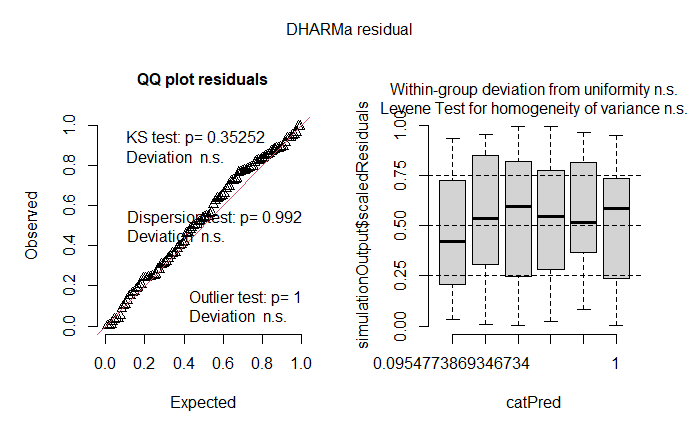

```r
# Survival

simulationOutput_surv_d<-simulateResiduals(glmer_surv_nc)
dharma_plot_surv<-plot(simulationOutput_surv_d)
```

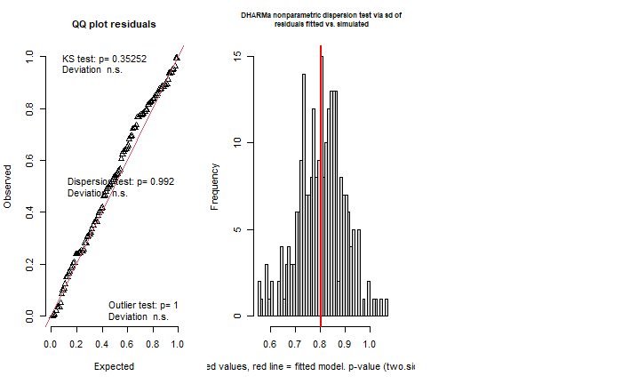

```
$uniformity

    Asymptotic one-sample Kolmogorov-Smirnov test

data:  simulationOutput$scaledResiduals
D = 0.089501, p-value = 0.3525
alternative hypothesis: two-sided


$dispersion

    DHARMa nonparametric dispersion test via sd of residuals fitted vs. simulated

data:  simulationOutput
dispersion = 1.004, p-value = 0.992
alternative hypothesis: two.sided


$outliers

    DHARMa bootstrapped outlier test

data:  simulationOutput
outliers at both margin(s) = 0, observations = 108, p-value = 1
alternative hypothesis: two.sided
 percent confidence interval:
 0 0
sample estimates:
outlier frequency (expected: 0 )
                               0
```

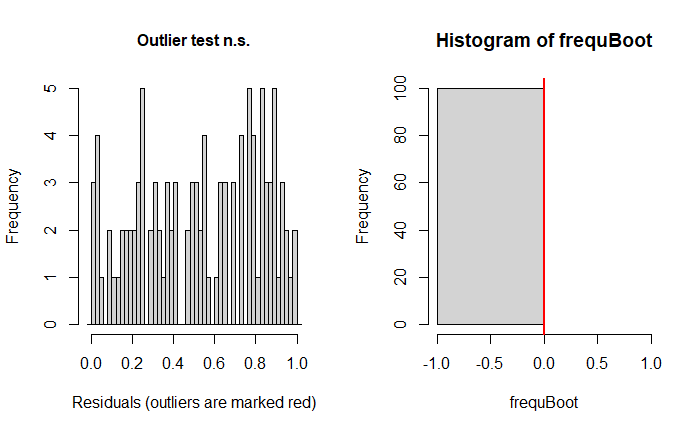

```r
surv_dharma<-testResiduals(simulationOutput_surv_d)
```

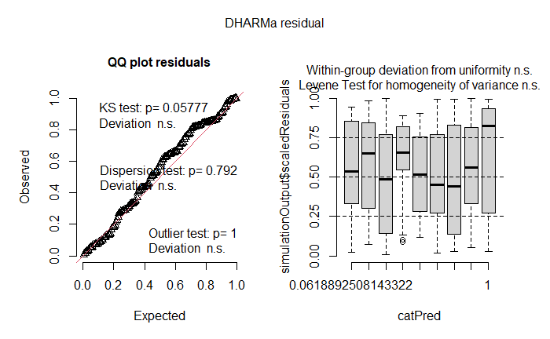

```r
# Flowering

simulationOutput_flow<-simulateResiduals(glmer_f)
dharma_plot_flow<-plot(simulationOutput_flow)
```

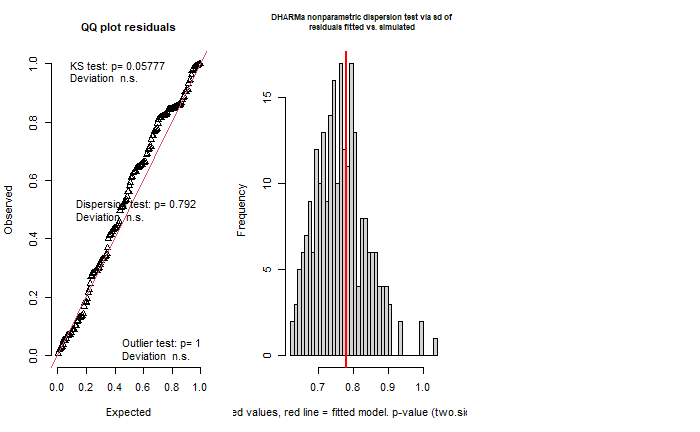

```
$uniformity

    Asymptotic one-sample Kolmogorov-Smirnov test

data:  simulationOutput$scaledResiduals
D = 0.10459, p-value = 0.05777
alternative hypothesis: two-sided


$dispersion

    DHARMa nonparametric dispersion test via sd of residuals fitted vs. simulated

data:  simulationOutput
dispersion = 1.0204, p-value = 0.792
alternative hypothesis: two.sided


$outliers

    DHARMa bootstrapped outlier test

data:  simulationOutput
outliers at both margin(s) = 0, observations = 162, p-value = 1
alternative hypothesis: two.sided
 percent confidence interval:
 0 0
sample estimates:
outlier frequency (expected: 0 )
                               0
```

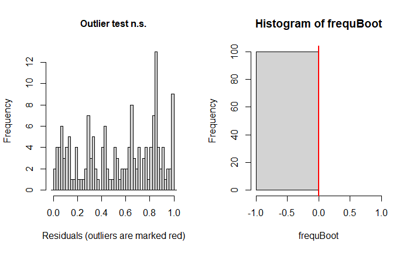

```r
flow_dharma<-testResiduals(simulationOutput_flow)
```

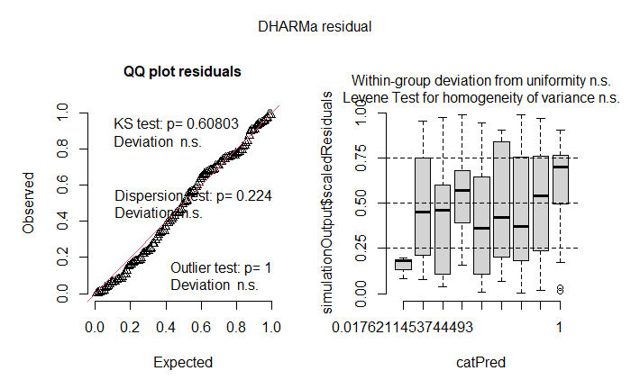

```r
# flower_count


simulationOutput_nflow<-simulateResiduals(glmer_nf_d)
dharma_plot_nflow<-plot(simulationOutput_nflow)
```

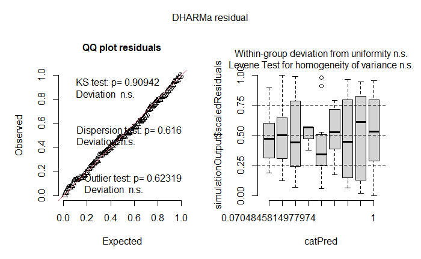

```r
# Height

simulationOutput_height_d<-simulateResiduals(lmer_height.o)
dharma_plot_height<-plot(simulationOutput_height_d)
```

```
$uniformity

    Asymptotic one-sample Kolmogorov-Smirnov test

data:  simulationOutput$scaledResiduals
D = 0.050951, p-value = 0.9094
alternative hypothesis: two-sided


$dispersion

    DHARMa nonparametric dispersion test via sd of residuals fitted vs. simulated

data:  simulationOutput
dispersion = 0.92956, p-value = 0.616
alternative hypothesis: two.sided


$outliers

    DHARMa outlier test based on exact binomial test with approximate expectations

data:  simulationOutput
outliers at both margin(s) = 1, observations = 122, p-value = 0.6232
alternative hypothesis: true probability of success is not equal to 0.007968127
95 percent confidence interval:
 0.0002075015 0.0448226574
sample estimates:
frequency of outliers (expected: 0.00796812749003984 )
                                           0.008196721
```

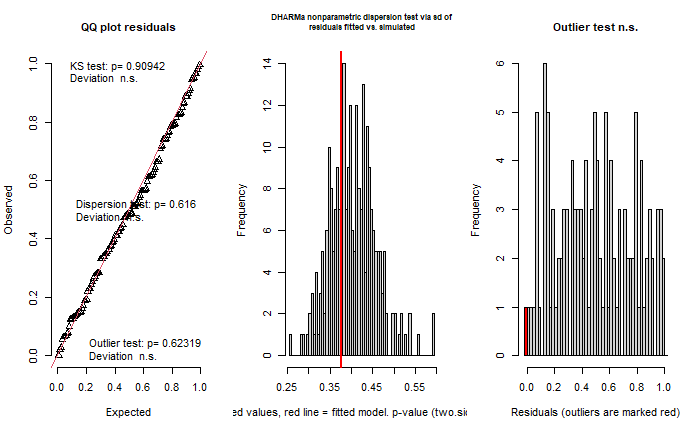

```r
height_dharma<-testResiduals(simulationOutput_height_d)
```

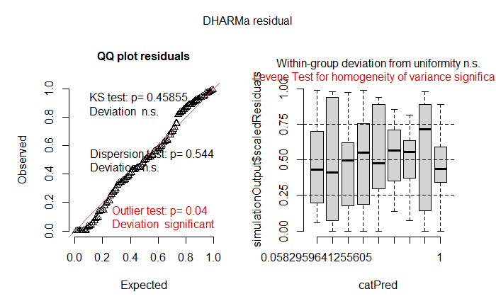

```r
# Bushiness

simulationOutput_bush_d<-simulateResiduals(glmer_bush)
dharma_plot_bush<-plot(simulationOutput_bush_d)
```

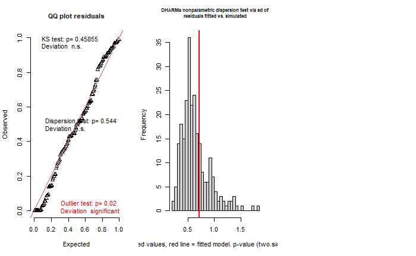

```
$uniformity

    Asymptotic one-sample Kolmogorov-Smirnov test

data:  simulationOutput$scaledResiduals
D = 0.078003, p-value = 0.4585
alternative hypothesis: two-sided


$dispersion

    DHARMa nonparametric dispersion test via sd of residuals fitted vs. simulated

data:  simulationOutput
dispersion = 1.1193, p-value = 0.544
alternative hypothesis: two.sided


$outliers

    DHARMa bootstrapped outlier test

data:  simulationOutput
outliers at both margin(s) = 7, observations = 120, p-value = 0.06
alternative hypothesis: two.sided
 percent confidence interval:
 0.00000000 0.05041667
sample estimates:
outlier frequency (expected: 0.0118333333333333 )
                                       0.05833333
```

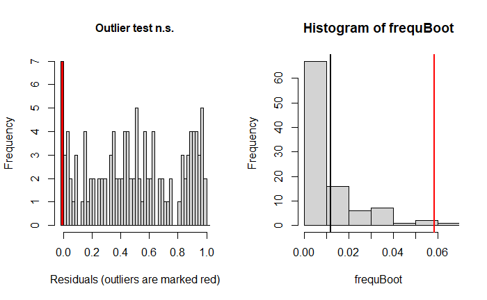

```r
bush_dharma<-testResiduals(simulationOutput_bush_d)
```

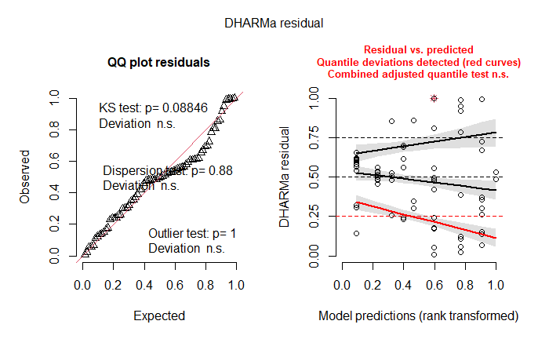

```r
# t flower

simulationOutput_tflow_d<-simulateResiduals(glmer_tf)
dharma_plot_tflow<-plot(simulationOutput_tflow_d)
```

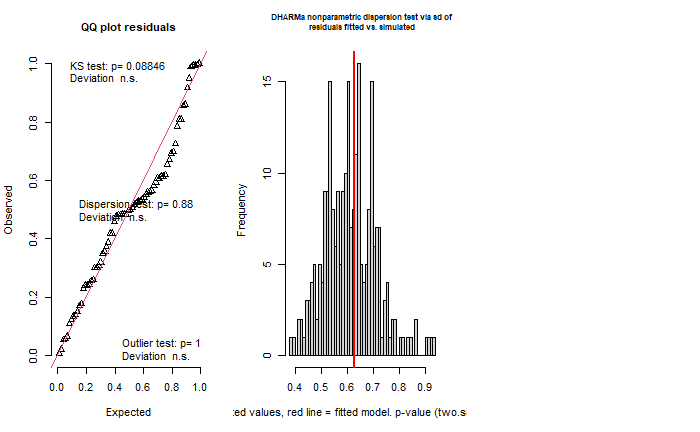

```
$uniformity

    Exact one-sample Kolmogorov-Smirnov test

data:  simulationOutput$scaledResiduals
D = 0.14474, p-value = 0.08846
alternative hypothesis: two-sided


$dispersion

    DHARMa nonparametric dispersion test via sd of residuals fitted vs. simulated

data:  simulationOutput
dispersion = 1.0219, p-value = 0.88
alternative hypothesis: two.sided


$outliers

    DHARMa bootstrapped outlier test

data:  simulationOutput
outliers at both margin(s) = 1, observations = 72, p-value = 1
alternative hypothesis: two.sided
 percent confidence interval:
 0.00000000 0.04166667
sample estimates:
outlier frequency (expected: 0.0106944444444444 )
                                       0.01388889
```

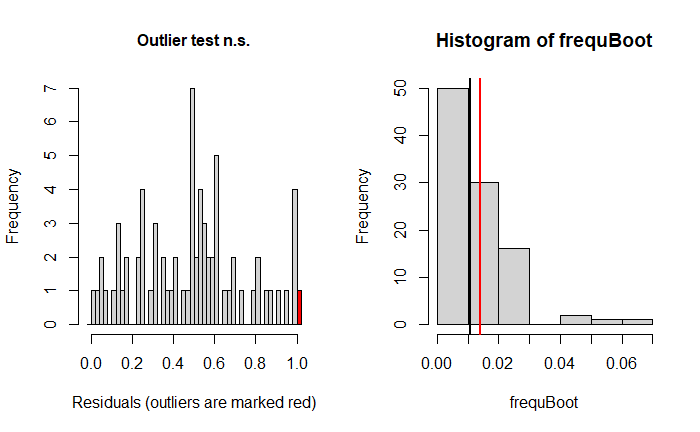

```r
tflow_dharma<-testResiduals(simulationOutput_tflow_d)
```

## Summary Anova tables

```r
s_surv<-car::Anova(glmer_surv_nc,type="II")
s_flow<-car::Anova(glmer_f,type="II")
s_nflow<-car::Anova(glmer_nf_d,type="II")
s_height<-car::Anova(lmer_height,type="III")
s_bush<-car::Anova(glmer_bush,type="III")
s_tflow<-car::Anova(glmer_tf,type="III")
#s_iheight<-car::Anova(lm_iheight_col,type="III")

options(scipen = 999)

surv<-as.data.frame(s_surv)
colnames(surv)[1] <- "Chisq"
surv <- cbind(surv,rep("survival", nrow(surv)))
colnames(surv)[ncol(surv)] = "trait"

flow<-as.data.frame(s_flow)
colnames(flow)[1] <- "Chisq"
flow <- cbind(flow,rep("flowering", nrow(flow)))
colnames(flow)[ncol(flow)] = "trait"


nflow<-as.data.frame(s_nflow)
nflow <- cbind(nflow,rep("n flowers", nrow(nflow)))
colnames(nflow)[ncol(nflow)] = "trait"


height<-as.data.frame(s_height)
height <- cbind(height,rep("height", nrow(height)))
colnames(height)[ncol(height)] = "trait"


bush<-as.data.frame(s_bush)
bush <- cbind(bush,rep("bushiness", nrow(bush)))
colnames(bush)[ncol(bush)] = "trait"


tflow<-as.data.frame(s_tflow)
colnames(tflow)[1] <- "Chisq"
tflow <- cbind(tflow,rep("time to flower", nrow(tflow)))
colnames(tflow)[ncol(tflow)] = "trait"


#iheight<-as.data.frame(s_iheight)

df_anovas <- rbind(surv,
      flow,
      nflow,
      tflow,
      height,
      bush)

df_anovas$"Pr(>Chisq)"<- round(df_anovas$"Pr(>Chisq)", 4)
df_anovas$"Chisq"<- round(df_anovas$"Chisq", 2)

df_anovas
```

|  | Chisq | Df | Pr(>Chisq) | trait |
| --- | --- | --- | --- | --- |
| trt | 2.50 | 1 | 0.1139 | survival |
| colors | 5.38 | 2 | 0.0678 | survival |
| trt:colors | 6.49 | 2 | 0.0391 | survival |
| trt1 | 17.11 | 2 | 0.0002 | flowering |
| colors1 | 10.46 | 2 | 0.0053 | flowering |
| trt:colors1 | 0.83 | 4 | 0.9339 | flowering |
| trt2 | 34.36 | 2 | 0.0000 | n flowers |
| colors2 | 6.06 | 2 | 0.0484 | n flowers |
| trt:colors2 | 3.92 | 4 | 0.4164 | n flowers |
| (Intercept) | 9686.46 | 1 | 0.0000 | time to flower |

[output cut: 11 more lines]

```r
#write.csv(df_anovas, "../tables/df_anovas_traits_delete.csv")
```

## Group comparisons of predicted means & plotting

Plotting settings

```r
my_theme<-theme(axis.text=element_text(size=12),
        axis.title = element_text(size = 14),
        legend.text=element_text(size=10),
        legend.title = element_text(size=12),
        plot.title = element_text(face="bold",size=14,margin=margin(0,0,20,0),hjust = 0.5),
        axis.title.y = element_text(hjust = 0.5),
        axis.title.x = element_text(hjust = 0.5))

pd = position_dodge(0.9)
alpha_raw_points = 0.15

trt_order <- c("control", "early drought", "late drought")

Dataset$trt <- factor(Dataset$trt,
    levels = trt_order,ordered = TRUE)
```

### —– Survival - all levels

Compute emmeans and CI

```r
marginal_surv1.1 = emmeans(glmer_surv_nc,
                   ~ colors:trt,  calc = c(n = ".wgt."))

back.emmeans_surv<-confint(marginal_surv1.1, type = "response")
```

Add letter display from tukey tests

```r
surv_emmeans_cld <- multcomp::cld(object = marginal_surv1.1,
                           Letters = letters)


surv_emmeans_cld <- surv_emmeans_cld %>%
  arrange(colors) %>%
  dplyr::select(trt, .group, colors)


back.emmeans_surv_all <- left_join(back.emmeans_surv, surv_emmeans_cld, by = c("trt","colors"))

back.emmeans_surv_all
```

```
 colors trt            prob     SE  df  n asymp.LCL asymp.UCL .group
 M_M    early drought 0.850 0.0914 Inf 18    0.5816     0.959   b
 M_Y    early drought 0.682 0.1275 Inf 18    0.4039     0.872  ab
 Y_Y    early drought 0.671 0.1321 Inf 18    0.3869     0.868  ab
 M_M    late drought  0.630 0.1321 Inf 18    0.3595     0.838  ab
 M_Y    late drought  0.142 0.0915 Inf 18    0.0364     0.419  a
 Y_Y    late drought  0.776 0.1095 Inf 18    0.5021     0.923   b

Confidence level used: 0.95
Intervals are back-transformed from the logit scale
```

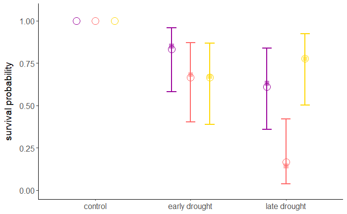

```r
Dataset_percentage <- aggregate(survived ~ trt + colors, data = Dataset, FUN = mean)

Dataset_percentage$trt <- factor(Dataset_percentage$trt,
   levels = trt_order,ordered = TRUE)



# Plotting raw data points
surv_raw <- ggdotchart(
  Dataset_percentage,
  x = "trt",
  y = "survived",
  color = "colors",
  palette = c("black", "black", "black"),
  alpha = 0.3,
  size = 5,
  shape = 21,
  #add = "segment",
  #add.params = list(color = "lightgray", size = 1.3),
  position = position_dodge(0.6),
  ggtheme = theme_classic(),
  sorting = "none",
  order = trt_order
)

# Overlay emmeans and CI on the raw data plot
surv_overlay_plot <- surv_raw +
  geom_errorbar(
    data = back.emmeans_surv,
    aes(
      x = trt, #factor(trt, levels = trt_order),
      y = prob,  # Assuming prob is the probability in decimal form
      ymin = asymp.LCL,
      ymax = asymp.UCL,
      color = colors
    ),
    position = position_dodge(width = 0.6),
    width = 0.3,
    size = 1
  ) +
  geom_point(
    data = back.emmeans_surv,
    aes(
      x = trt, #factor(trt, levels = trt_order),
      y = prob,  # Assuming prob is the probability in decimal form
      color = colors
    ),
    position = position_dodge(width = 0.6),
    size = 3,
    alpha = 0.5,
    shape = 15
  ) +
 #geom_text(
  #  data = back.emmeans_surv,
  #  aes(
  #    x = trt, # Adjust position based on factor levels,
  #    color = colors,
  #    y = asymp.UCL + 0.02,  # Adjust the position of the letters
 #     label = .group  # Use the .group column for labels
 #   ),
 #   position = position_dodge(width = 0.6),
 #   vjust = -0.5,  # Adjust vertical position
 #   size = 4
 # ) +
  scale_fill_manual(values = c("#990099", "#FF6666", "gold")) +
  scale_color_manual(
    values = c("#990099", "#FF6666", "gold"),  # Remove black color
    labels = c("pseudomajus", "F1 Hybrid", "striatum")  # Update labels
  ) +
  ylim(0,1.05)+
  theme_classic() +
  my_theme +
  guides(fill = FALSE) +
  #labs(color = "Phenotype") +
  theme(legend.position = "none") +
  xlab(NULL) +
  ylab("survival probability") +
  theme(axis.title.y = element_text(margin = margin(r = 10)))
surv_overlay_plot
```

```r
# First, ensure you're using the joined data frame with .group letters
back.emmeans_surv_all$label_y <- back.emmeans_surv_all$asymp.UCL + 0.05  # Small vertical offset

# Add this to your plot
surv_overlay_plot <- surv_overlay_plot +
  geom_text(
    data = back.emmeans_surv_all,
    aes(
      x = trt,
      y = label_y,
      label = .group,
      color = colors
    ),
    position = position_dodge(width = 0.6),
    vjust = 0,
    size = 4
  )
```

### —– Survival - significant levels

Compute emmeans and CI

```r
marginal_surv1.1 = emmeans(glmer_surv_nc,
                   ~ colors,  calc = c(n = ".wgt."))
```

```
NOTE: Results may be misleading due to involvement in interactions
```

```r
back.emmeans_surv<-confint(marginal_surv1.1, type = "response")
```

Add letter display from tukey tests

```r
surv_emmeans_cld <- multcomp::cld(object = marginal_surv1.1,
                           Letters = letters)


surv_emmeans_cld <- surv_emmeans_cld %>%
  arrange(colors) %>%
  dplyr::select(.group, colors)


back.emmeans_surv <- left_join(back.emmeans_surv, surv_emmeans_cld, by = c("colors"))

back.emmeans_surv
```

```
 colors  prob     SE  df  n asymp.LCL asymp.UCL .group
 M_M    0.757 0.0856 Inf 36     0.556     0.886   b
 M_Y    0.373 0.1090 Inf 36     0.193     0.597  a
 Y_Y    0.727 0.0864 Inf 36     0.531     0.862   b

Results are averaged over the levels of: trt
Confidence level used: 0.95
Intervals are back-transformed from the logit scale
```

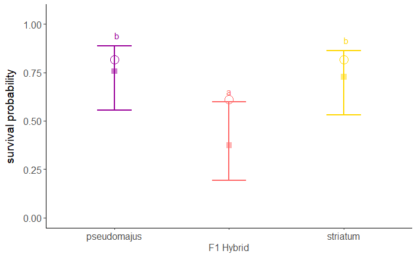

```r
Dataset_percentage <- aggregate(survived ~ colors, data = Dataset, FUN = mean)



# Plotting raw data points
surv_raw <- ggdotchart(
  Dataset_percentage,
  x = "colors",
  y = "survived",
  color = "colors",
  palette = c("black", "black", "black"),
  alpha = 0.3,
  size = 5,
  shape = 21,
  #add = "segment",
  #add.params = list(color = "lightgray", size = 1.3),
  position = position_dodge(0.6),
  ggtheme = theme_classic(),
  sorting = "none"
)

# Overlay emmeans and CI on the raw data plot
surv_overlay_plot2 <- surv_raw +
  geom_errorbar(
    data = back.emmeans_surv,
    aes(
      x = colors, #factor(trt, levels = trt_order),
      y = prob,  # Assuming prob is the probability in decimal form
      ymin = asymp.LCL,
      ymax = asymp.UCL,
      color = colors
    ),
    position = position_dodge(width = 0.6),
    width = 0.3,
    size = 1
  ) +
  geom_point(
    data = back.emmeans_surv,
    aes(
      x = colors, #factor(trt, levels = trt_order),
      y = prob,  # Assuming prob is the probability in decimal form
      color = colors
    ),
    position = position_dodge(width = 0.6),
    size = 3,
    alpha = 0.5,
    shape = 15
  ) +
 geom_text(
    data = back.emmeans_surv,
    aes(
      x = colors, # Adjust position based on factor levels,
      color = colors,
     y = asymp.UCL + 0.02,  # Adjust the position of the letters
      label = .group  # Use the .group column for labels
    ),
    position = position_dodge(width = 0.6),
   vjust = -0.5,  # Adjust vertical position
   size = 4
  ) +
  scale_fill_manual(values = c("#990099", "#FF6666", "gold")) +
  scale_color_manual(
    values = c("#990099", "#FF6666", "gold"),  # Remove black color
   # labels = c("pseudomajus", "F1 Hybrid", "striatum")  # Update labels
  ) +
  ylim(0,1.05)+
  theme_classic() +
  my_theme +
  guides(fill = FALSE) +
  theme(legend.position = "none") +
  ylab("survival probability") +
  xlab(NULL)+
  theme(axis.title.y = element_text(margin = margin(r = 10)))+
   scale_x_discrete(guide = guide_axis(n.dodge=2),
                    labels = c("pseudomajus", "F1 Hybrid", "striatum"))
surv_overlay_plot2
```

```r
NA
NA
NA
NA
NA
NA
```

### —– Flowering - All levels

Compute emmeans and CI

```r
emmeans_flowering = emmeans(glmer_f,
                   ~ colors:trt,  calc = c(n = ".wgt."))

back.emmeans_flowering<-confint(emmeans_flowering, type = "response")
```

Add letter display from tukey tests

```r
flow_emmeans_cld <- multcomp::cld(object = emmeans_flowering,
                           Letters = letters)

flow_emmeans_cld <- flow_emmeans_cld %>%
  arrange(trt, colors) %>%
  dplyr::select(.group, colors, trt)


back.emmeans_flowering_all <- left_join(back.emmeans_flowering, flow_emmeans_cld, by = c("trt", "colors"))

back.emmeans_flowering_all
```

```
 colors trt             prob     SE  df  n asymp.LCL asymp.UCL .group
 M_M    control       0.6334 0.1398 Inf 18    0.3468     0.849  ab
 M_Y    control       0.9070 0.0712 Inf 18    0.6508     0.981   b
 Y_Y    control       0.5042 0.1493 Inf 18    0.2398     0.766  ab
 M_M    early drought 0.0964 0.0734 Inf 18    0.0200     0.358  a
 M_Y    early drought 0.4413 0.1471 Inf 18    0.1970     0.718  ab
 Y_Y    early drought 0.1344 0.0898 Inf 18    0.0331     0.413  a
 M_M    late drought  0.2468 0.1210 Inf 18    0.0838     0.540  a
 M_Y    late drought  0.6864 0.1319 Inf 18    0.3970     0.879  ab
 Y_Y    late drought  0.3034 0.1322 Inf 18    0.1133     0.598  ab

Confidence level used: 0.95
Intervals are back-transformed from the logit scale
```

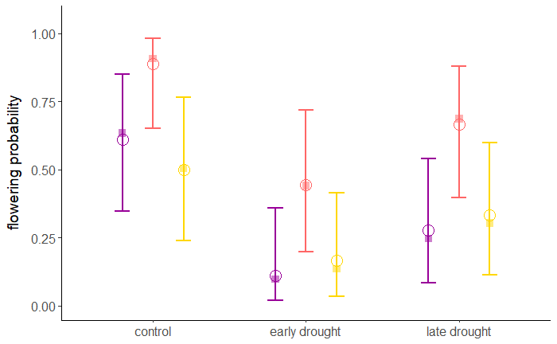

```r
Dataset_percentage <- aggregate(flowering ~ trt + colors, data = Dataset, FUN = mean)


# Plotting raw data points
flow_raw <- ggdotchart(
  Dataset_percentage,
  x = "trt",
  y = "flowering",
  color = "colors",
  palette = c("black", "black", "black"),
  alpha = 0.3,
  size = 5,
  shape = 21,
  #add = "segment",
  #add.params = list(color = "lightgray", size = 1.3),
  position = position_dodge(0.6),
  ggtheme = theme_classic(),
    sorting = "none",
  order = trt_order
)

# Overlay emmeans and CI on the raw data plot
flow_overlay_plot <- flow_raw +
  geom_errorbar(
    data = back.emmeans_flowering,
    aes(
      x = trt, #factor(trt, levels = c(trt_order)),
      y = prob,  # Assuming prob is the probability in decimal form
      ymin = asymp.LCL,
      ymax = asymp.UCL,
      color = colors
    ),
    position = position_dodge(width = 0.6),
    width = 0.3,
    size = 1
  ) +
  geom_point(
    data = back.emmeans_flowering,
    aes(
      x = trt, #factor(trt, levels = c(trt_order)),
      y = prob,  # Assuming prob is the probability in decimal form
      color = colors
    ),
    position = position_dodge(width = 0.6),
    size = 3,
    alpha = 0.5,
    shape = 15
  ) +
 # geom_text(
 #   data = back.emmeans_flowering,
 #   aes(
 #     x = trt, # Adjust position based on factor levels,
  #    color = colors,
  #    y = asymp.UCL + 0.02,  # Adjust the position of the letters
  #    label = .group  # Use the .group column for labels
 #   ),
 #   position = position_dodge(width = 0.6),
 #   vjust = -0.5,  # Adjust vertical position
 #   size = 4
#  ) +
  scale_fill_manual(values = c("#990099", "#FF6666", "gold")) +
  scale_color_manual(
    values = c("#990099", "#FF6666", "gold"),  # Remove black color
    labels = c("pseudomajus", "F1 Hybrid", "striatum")  # Update labels
  ) +
  ylim(0, 1.05)+
  theme_classic() +
  my_theme +
  guides(fill = FALSE) +
  #labs(color = "Phenotype") +
  theme(legend.position = "none")+
  xlab(NULL) +
  ylab("flowering probability") +
  theme(axis.title.y = element_text(margin = margin(r = 10)))
flow_overlay_plot
```

### —– Flowering - significant levels

#### colors

Compute emmeans and CI

```r
emmeans_flowering = emmeans(glmer_f,
                   ~ colors,  calc = c(n = ".wgt."))
```

```
NOTE: Results may be misleading due to involvement in interactions
```

```r
back.emmeans_flowering<-confint(emmeans_flowering, type = "response")
```

Add letter display from tukey tests

```r
flow_emmeans_cld <- multcomp::cld(object = emmeans_flowering,
                           Letters = letters)

flow_emmeans_cld <- flow_emmeans_cld %>%
  arrange(colors) %>%
  dplyr::select(.group, colors)


back.emmeans_flowering <- left_join(back.emmeans_flowering, flow_emmeans_cld, by = "colors")

back.emmeans_flowering
```

```
 colors  prob     SE  df  n asymp.LCL asymp.UCL .group
 M_M    0.282 0.0944 Inf 54     0.136     0.495  a
 M_Y    0.719 0.0937 Inf 54     0.508     0.864   b
 Y_Y    0.291 0.0937 Inf 54     0.144     0.500  a

Results are averaged over the levels of: trt
Confidence level used: 0.95
Intervals are back-transformed from the logit scale
```

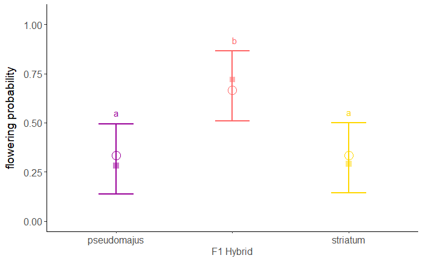

```r
Dataset_percentage <- aggregate(flowering ~ colors, data = Dataset, FUN = mean)


# Plotting raw data points
flow_raw <- ggdotchart(
  Dataset_percentage,
  x = "colors",
  y = "flowering",
  color = "colors",
  palette = c("black", "black", "black"),
  alpha = 0.3,
  size = 5,
  shape = 21,
  #add = "segment",
  #add.params = list(color = "lightgray", size = 1.3),
  position = position_dodge(0.6),
  ggtheme = theme_classic(),
    sorting = "none"
)

# Overlay emmeans and CI on the raw data plot
flow_overlay_plot2 <- flow_raw +
  geom_errorbar(
    data = back.emmeans_flowering,
    aes(
      x = colors, #factor(trt, levels = c(trt_order)),
      y = prob,  # Assuming prob is the probability in decimal form
      ymin = asymp.LCL,
      ymax = asymp.UCL,
      color = colors
    ),
    position = position_dodge(width = 0.6),
    width = 0.3,
    size = 1
  ) +
  geom_point(
    data = back.emmeans_flowering,
    aes(
      x = colors, #factor(trt, levels = c(trt_order)),
      y = prob,  # Assuming prob is the probability in decimal form
      color = colors
    ),
    position = position_dodge(width = 0.6),
    size = 3,
    alpha = 0.5,
    shape = 15
  ) +
  geom_text(
    data = back.emmeans_flowering,
    aes(
      x = colors, # Adjust position based on factor levels,
      color = colors,
      y = asymp.UCL + 0.02,  # Adjust the position of the letters
      label = .group  # Use the .group column for labels
    ),
    position = position_dodge(width = 0.6),
    vjust = -0.5,  # Adjust vertical position
    size = 4
 ) +
  scale_fill_manual(values = c("#990099", "#FF6666", "gold")) +
  scale_color_manual(
    values = c("#990099", "#FF6666", "gold"),  # Remove black color
    labels = c("pseudomajus", "F1 Hybrid", "striatum")  # Update labels
  ) +
  ylim(0, 1.05)+
  theme_classic() +
  my_theme +
  guides(fill = FALSE) +
  #labs(color = "Phenotype") +
  theme(legend.position = "none") +
  xlab(NULL) +
  ylab("flowering probability") +
  theme(axis.title.y = element_text(margin = margin(r = 10)))+
   scale_x_discrete(guide = guide_axis(n.dodge=2),
                    labels = c("pseudomajus", "F1 Hybrid", "striatum"))
flow_overlay_plot2
```

#### trt

Compute emmeans and CI

```r
emmeans_flowering = emmeans(glmer_f,
                   ~ trt,  calc = c(n = ".wgt."))
```

```
NOTE: Results may be misleading due to involvement in interactions
```

```r
back.emmeans_flowering<-confint(emmeans_flowering, type = "response")
```

Add letter display from tukey tests

```r
flow_emmeans_cld <- multcomp::cld(object = emmeans_flowering,
                           Letters = letters)

flow_emmeans_cld <- flow_emmeans_cld %>%
  arrange(trt) %>%
  dplyr::select(.group, trt)


back.emmeans_flowering <- left_join(back.emmeans_flowering, flow_emmeans_cld, by = "trt")

back.emmeans_flowering
```

```
 trt            prob     SE  df  n asymp.LCL asymp.UCL .group
 control       0.721 0.0830 Inf 54    0.5347     0.853   b
 early drought 0.191 0.0694 Inf 54    0.0889     0.363  a
 late drought  0.404 0.0902 Inf 54    0.2457     0.586  a

Results are averaged over the levels of: colors
Confidence level used: 0.95
Intervals are back-transformed from the logit scale
```

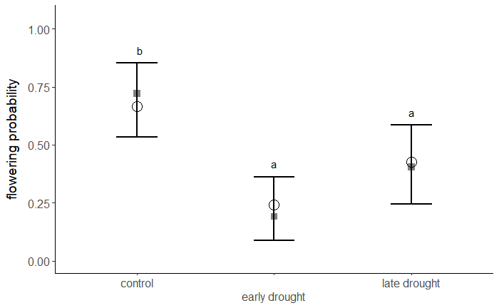

```r
Dataset_percentage <- aggregate(flowering ~ trt, data = Dataset, FUN = mean)


# Plotting raw data points
flow_raw <- ggdotchart(
  Dataset_percentage,
  x = "trt",
  y = "flowering",
  #color = "colors",
  palette = c("black", "black", "black"),
  alpha = 0.3,
  size = 5,
  shape = 21,
  #add = "segment",
  #add.params = list(color = "lightgray", size = 1.3),
  position = position_dodge(0.6),
  ggtheme = theme_classic(),
    sorting = "none"
)

# Overlay emmeans and CI on the raw data plot
flow_overlay_plot3 <- flow_raw +
  geom_errorbar(
    data = back.emmeans_flowering,
    aes(
      x = trt, #factor(trt, levels = c(trt_order)),
      y = prob,  # Assuming prob is the probability in decimal form
      ymin = asymp.LCL,
      ymax = asymp.UCL,
    #  color = colors
    ),
    position = position_dodge(width = 0.6),
    width = 0.3,
    size = 1
  ) +
  geom_point(
    data = back.emmeans_flowering,
    aes(
      x = trt, #factor(trt, levels = c(trt_order)),
      y = prob,  # Assuming prob is the probability in decimal form
   #   color = colors
    ),
    position = position_dodge(width = 0.6),
    size = 3,
    alpha = 0.5,
    shape = 15
  ) +
  geom_text(
    data = back.emmeans_flowering,
    aes(
      x = trt, # Adjust position based on factor levels,
     # color = colors,
      y = asymp.UCL + 0.02,  # Adjust the position of the letters
      label = .group  # Use the .group column for labels
    ),
    position = position_dodge(width = 0.6),
    vjust = -0.5,  # Adjust vertical position
    size = 4
 ) +
 # scale_fill_manual(values = c("#990099", "#FF6666", "gold")) +
 # scale_color_manual(
#    values = c("#990099", "#FF6666", "gold"),  # Remove black color
#    labels = c("pseudomajus", "F1 Hybrid", "striatum")  # Update labels
#  ) +
  ylim(0, 1.05)+
  theme_classic() +
  my_theme +
  guides(fill = FALSE) +
  labs(color = "Phenotype") +
  xlab(NULL) +
  ylab("flowering probability") +
  theme(axis.title.y = element_text(margin = margin(r = 10)))+
   scale_x_discrete(guide = guide_axis(n.dodge=2))


flow_overlay_plot3
```

### —– N flowers - All levels

Compute emmeans and CI

```r
### N flowers (1 drought level) - treatment significant

marginal_nf.d = emmeans(glmer_nf_d,
                   ~ colors:trt,  calc = c(n = ".wgt."))

back.emmeans_nflow<-confint(marginal_nf.d, type = "response")


back.emmeans_nflow[which(is.infinite(back.emmeans_nflow$asymp.UCL)),"asymp.UCL"] <- 0
```

Add letter display from tukey tests

```r
nflow_emmeans_cld <- multcomp::cld(object = marginal_nf.d,
                           Letters = letters)

nflow_emmeans_cld <- nflow_emmeans_cld %>%
  arrange(trt, colors) %>%
  dplyr::select(.group, colors, trt)


back.emmeans_nflow_all <- left_join(back.emmeans_nflow, nflow_emmeans_cld, by = c("trt", "colors"))

back.emmeans_nflow_all
```

```
 colors trt           response        SE  df  n asymp.LCL asymp.UCL .group
 M_M    control         3.7778 1.3030769 Inf 18   1.92145     7.428   bc
 M_Y    control         6.1667 2.0755316 Inf 18   3.18830    11.927    c
 Y_Y    control         3.0000 1.0512458 Inf 18   1.50955     5.962   bc
 M_M    early drought   0.0667 0.0707146 Inf 15   0.00834     0.533  a
 M_Y    early drought   1.1667 0.5568770 Inf 12   0.45777     2.973  abc
 Y_Y    early drought   0.3077 0.1932290 Inf 13   0.08986     1.054  a
 M_M    late drought    0.5455 0.3167838 Inf 11   0.17475     1.703  ab
 M_Y    late drought    0.0000 0.0000513 Inf  3   0.00000     0.000  abc
 Y_Y    late drought    0.8571 0.3996508 Inf 14   0.34369     2.138  ab

Confidence level used: 0.95
Intervals are back-transformed from the log scale
```

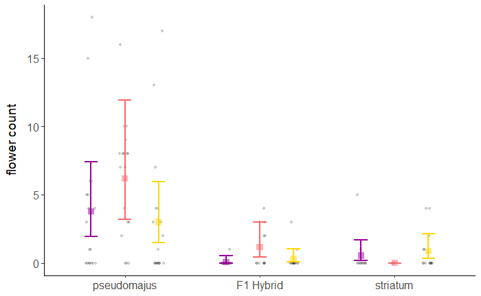

```r
nflow_raw <- ggplot(Dataset, aes(x = trt, y = flower_count, group = colors)) +
  geom_jitter(
    aes(color = "black", fill = "black"),
    position = position_jitterdodge(0.08),
    size = 1.2,
    alpha = alpha_raw_points
  ) +
  scale_fill_manual(values=c("black", "black", "black"))+
  scale_color_manual(values=c("black", "black", "black"))+
  theme_classic() +
  my_theme





# Overlay emmeans and CI on the raw data plot
nflow_overlay_plot <- nflow_raw +
  geom_errorbar(
    data = back.emmeans_nflow,
    aes(x = trt, y = response, ymin = asymp.LCL, ymax = asymp.UCL, color = colors),
    position = position_dodge(width = 0.75),
    width = 0.3,
    size = 1
  ) +

  geom_point(
    data = back.emmeans_nflow,
    aes(x = trt, y = response, color = colors),
    position = position_dodge(width = 0.75),
    size = 3,
    alpha = 0.5,
    shape = 15

  ) +
#  geom_text(
 #   data = back.emmeans_nflow,
 #   aes(
 #     x = trt, # Adjust position based on factor levels,
 #     color = colors,
 #     y = asymp.UCL + 0.1,  # Adjust the position of the letters
 #     label = .group  # Use the .group column for labels
  #  ),
 #   position = position_dodge(width = 0.75),
 #   vjust = -0.5,  # Adjust vertical position
 #   size = 4
#  ) +
    scale_fill_manual(values=c("#990099", "#FF6666", "gold"))+
  scale_color_manual(values=c("#990099", "#FF6666", "gold","black"),labels = c("raw data", "pseudomajus", "F1 hybrid", "striatum"))+
  theme_classic()+
  my_theme+
guides(fill = FALSE)+
#labs(color = "phenotype")+
  theme(legend.position = "none") +
  scale_x_discrete(labels = c("pseudomajus", "F1 Hybrid", "striatum")) +
  xlab(NULL)+
  ylab("flower count")+
  theme(axis.title.y = element_text(margin = margin(r = 10)))
nflow_overlay_plot
```

```r
NA
NA
```

### —– N flowers - significant levels

#### colors

Compute emmeans and CI

```r
### N flowers (1 drought level) - treatment significant

marginal_nf.d = emmeans(glmer_nf_d,
                   ~ colors,  calc = c(n = ".wgt."))
```

```
NOTE: Results may be misleading due to involvement in interactions
```

```r
back.emmeans_nflow<-confint(marginal_nf.d, type = "response")


back.emmeans_nflow[which(is.infinite(back.emmeans_nflow$asymp.UCL)),"asymp.UCL"] <- 0
```

Add letter display from tukey tests

```r
nflow_emmeans_cld <- multcomp::cld(object = marginal_nf.d,
                           Letters = letters)

nflow_emmeans_cld <- nflow_emmeans_cld %>%
  arrange(colors) %>%
  dplyr::select(.group, colors)


back.emmeans_nflow <- left_join(back.emmeans_nflow, nflow_emmeans_cld, by =  "colors")

# we manually assign a different letter to hybrids because they have 0 flowers

back.emmeans_nflow[back.emmeans_nflow$colors == "M_Y", ".group"] <- "b"

back.emmeans_nflow
```

```
 colors response    SE  df  n asymp.LCL asymp.UCL .group
 M_M     0.51598 0.216 Inf 44     0.227      1.17  a
 M_Y     0.00385 8.324 Inf 33     0.000      0.00 b
 Y_Y     0.92490 0.264 Inf 45     0.528      1.62  a

Results are averaged over the levels of: trt
Confidence level used: 0.95
Intervals are back-transformed from the log scale
```

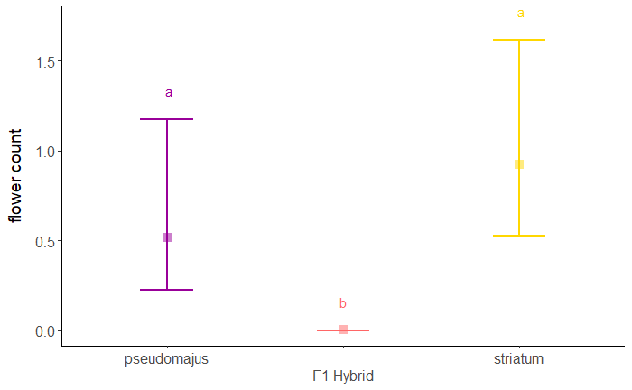

```r
# Overlay emmeans and CI on the raw data plot
nflow_overlay_plot2 <- ggplot(back.emmeans_nflow, aes(x = colors, y = response, group = colors)) +
  #nflow_raw +
  geom_errorbar(
    data = back.emmeans_nflow,
    aes(x = colors, y = response, ymin = asymp.LCL, ymax = asymp.UCL, color = colors),
    position = position_dodge(width = 0.75),
    width = 0.3,
    size = 1
  ) +

  geom_point(
    data = back.emmeans_nflow,
    aes(x = colors, y = response, color = colors),
    position = position_dodge(width = 0.75),
    size = 3,
    alpha = 0.5,
    shape = 15

  ) +
 geom_text(
    data = back.emmeans_nflow,
    aes(
      x = colors, # Adjust position based on factor levels,
      color = colors,
      y = asymp.UCL + 0.1,  # Adjust the position of the letters
      label = .group  # Use the .group column for labels
    ),
    position = position_dodge(width = 0.75),
    vjust = -0.5,  # Adjust vertical position
    size = 4
  ) +
    scale_fill_manual(values=c("#990099", "#FF6666", "gold"))+
  scale_color_manual(values=c("#990099", "#FF6666", "gold"),labels = c("pseudomajus", "F1 hybrid", "striatum"))+
  theme_classic()+
  my_theme+
guides(fill = FALSE)+
#labs(color = "phenotype")+
  theme(legend.position = "none") +
  xlab(NULL)+
  ylab("flower count")+
  theme(axis.title.y = element_text(margin = margin(r = 10)))+
   scale_x_discrete(guide = guide_axis(n.dodge=2),
                    labels = c("pseudomajus", "F1 Hybrid", "striatum"))


nflow_overlay_plot2
```

```r
NA
NA
```

#### trt

Compute emmeans and CI

```r
### N flowers (1 drought level) - treatment significant

marginal_nf.d = emmeans(glmer_nf_d,
                   ~ trt,  calc = c(n = ".wgt."))
```

```
NOTE: Results may be misleading due to involvement in interactions
```

```r
back.emmeans_nflow<-confint(marginal_nf.d, type = "response")


back.emmeans_nflow[which(is.infinite(back.emmeans_nflow$asymp.UCL)),"asymp.UCL"] <- 0
```

Add letter display from tukey tests

```r
nflow_emmeans_cld <- multcomp::cld(object = marginal_nf.d,
                           Letters = letters)

nflow_emmeans_cld <- nflow_emmeans_cld %>%
  arrange(trt) %>%
  dplyr::select(.group, trt)


back.emmeans_nflow <- left_join(back.emmeans_nflow, nflow_emmeans_cld, by =  "trt")

# manually assign different letter to late drought

back.emmeans_nflow[back.emmeans_nflow$trt == "late drought", ".group"] <- "c"

back.emmeans_nflow
```

```
 trt           response    SE  df  n asymp.LCL asymp.UCL .group
 control        4.11910 0.818 Inf 54     2.791     6.080   b
 early drought  0.28818 0.127 Inf 40     0.122     0.683  a
 late drought   0.00155 3.346 Inf 28     0.000     0.000 c

Results are averaged over the levels of: colors
Confidence level used: 0.95
Intervals are back-transformed from the log scale
```

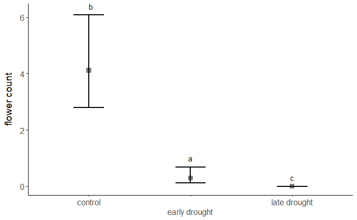

```r
# Overlay emmeans and CI on the raw data plot
nflow_overlay_plot3 <- ggplot(back.emmeans_nflow, aes(x = trt, y = response)) +
  #nflow_raw +
  geom_errorbar(
    data = back.emmeans_nflow,
    aes(x = trt, y = response, ymin = asymp.LCL, ymax = asymp.UCL),
    position = position_dodge(width = 0.75),
    width = 0.3,
    size = 1
  ) +

  geom_point(
    data = back.emmeans_nflow,
    aes(x = trt, y = response),
    position = position_dodge(width = 0.75),
    size = 3,
    alpha = 0.5,
    shape = 15

  ) +
 geom_text(
    data = back.emmeans_nflow,
    aes(
      x = trt, # Adjust position based on factor levels,
      y = asymp.UCL + 0.1,  # Adjust the position of the letters
      label = .group  # Use the .group column for labels
    ),
    position = position_dodge(width = 0.75),
    vjust = -0.5,  # Adjust vertical position
    size = 4
  ) +
  theme_classic()+
  my_theme+
guides(fill = FALSE)+
labs(color = "phenotype")+
  xlab(NULL)+
  ylab("flower count")+
  theme(axis.title.y = element_text(margin = margin(r = 10)))+
   scale_x_discrete(guide = guide_axis(n.dodge=2))


nflow_overlay_plot3
```

```r
NA
NA
```

### —– Height

```r
emmeans_height = emmeans(lmer_height,
                   ~ colors:trt,  calc = c(n = ".wgt."))

emmeans_height <- multcomp::cld(object = emmeans_height,
                                   Letters = letters)
```

RAW DATA

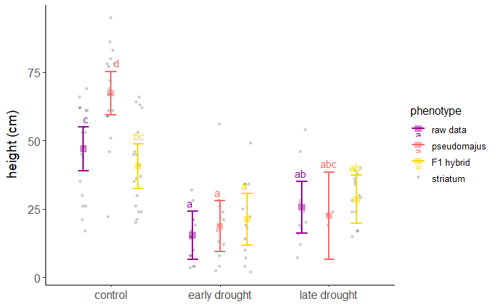

```r
height_raw <- ggplot(Dataset, aes(x = trt, y = height_cm, group = colors)) +
  geom_jitter(
    aes(color = "black", fill = "black"),
    position = position_jitterdodge(0.08),
    size = 1.2,
    alpha = alpha_raw_points
  ) +
  scale_fill_manual(values=c("black", "black", "black"))+
  scale_color_manual(values=c("black", "black", "black"))+
  theme_classic() +
  my_theme





# Overlay emmeans and CI on the raw data plot
height_overlay_plot <- height_raw +
  geom_errorbar(
    data = emmeans_height,
    aes(x = trt, y = emmean, ymin = lower.CL, ymax = upper.CL, color = colors),
    position = position_dodge(width = 0.75),
    width = 0.3,
    size = 1
  ) +

  geom_point(
    data = emmeans_height,
    aes(x = trt, y = emmean, color = colors),
    position = position_dodge(width = 0.75),
    size = 3,
    alpha = 0.5,
    shape = 15

  ) +
  geom_text(
    data = emmeans_height,
    aes(
      x = trt, # Adjust position based on factor levels,
      color = colors,
      y = upper.CL + 0.1,  # Adjust the position of the letters
      label = .group  # Use the .group column for labels
    ),
    position = position_dodge(width = 0.75),
    vjust = -0.5,  # Adjust vertical position
    size = 4
  ) +
    scale_fill_manual(values=c("#990099", "#FF6666", "gold"))+
  scale_color_manual(values=c("#990099", "#FF6666", "gold","black"),labels = c("raw data", "pseudomajus", "F1 hybrid", "striatum"))+
  theme_classic()+
  my_theme+
guides(fill = FALSE)+
labs(color = "phenotype")+
  xlab(NULL)+
  ylab("height (cm)")+
  theme(axis.title.y = element_text(margin = margin(r = 10)))
height_overlay_plot
```

```r
NA
NA
```

### —– Bushiness

Compute emmeans and CI

```r
emmeans_bush = emmeans(glmer_bush,
                   ~ colors:trt,  calc = c(n = ".wgt."))

back.emmeans_bush<-confint(emmeans_bush, type = "response")
```

Add letter display from tukey tests

```r
emmeans_bush_cld <- multcomp::cld(object = emmeans_bush,
                                   Letters = letters)

emmeans_bush_cld <- emmeans_bush_cld %>%
  arrange(trt, colors) %>%
  dplyr::select(.group, colors, trt)


back.emmeans_bush <- left_join(back.emmeans_bush, emmeans_bush_cld, by = c("trt", "colors"))

back.emmeans_bush
```

```
 colors trt           rate   SE  df  n asymp.LCL asymp.UCL .group
 M_M    control       32.1 4.89 Inf 17     23.82      43.3    cd
 M_Y    control       22.8 3.50 Inf 18     16.89      30.8   bcd
 Y_Y    control       40.5 6.12 Inf 18     30.11      54.5     d
 M_M    early drought 16.7 2.94 Inf 15     11.82      23.6  ab
 M_Y    early drought 12.4 2.28 Inf 12      8.61      17.7  a
 Y_Y    early drought 20.8 3.74 Inf 13     14.66      29.6  abc
 M_M    late drought  22.1 3.61 Inf 10     16.07      30.5  ab
 M_Y    late drought  25.0 4.86 Inf  3     17.08      36.6   bcd
 Y_Y    late drought  25.5 3.99 Inf 14     18.74      34.6  abc

Confidence level used: 0.95
Intervals are back-transformed from the log scale
```

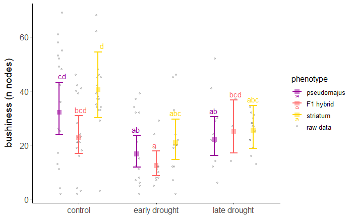

```r
bush_raw <- ggplot(Dataset, aes(x = trt, y = bushiness, group = colors)) +
  geom_jitter(
    aes(color = "black", fill = "black"),
    position = position_jitterdodge(0.08),
    size = 1.2,
    alpha = alpha_raw_points
  ) +
  scale_fill_manual(values=c("black", "black", "black"))+
  scale_color_manual(values=c("black", "black", "black"))+
  theme_classic() +
  my_theme





# Overlay emmeans and CI on the raw data plot
bushiness_overlay_plot <- bush_raw +
  geom_errorbar(
    data = back.emmeans_bush,
    aes(x = trt, y = rate, ymin = asymp.LCL, ymax = asymp.UCL, color = colors),
    position = position_dodge(width = 0.75),
    width = 0.3,
    size = 1
  ) +

  geom_point(
    data = back.emmeans_bush,
    aes(x = trt, y = rate, color = colors),
    position = position_dodge(width = 0.75),
    size = 3,
    alpha = 0.5,
    shape = 15

  ) +
  geom_text(
    data = back.emmeans_bush,
    aes(
      x = trt, # Adjust position based on factor levels,
      color = colors,
      y = asymp.UCL + 0.1,  # Adjust the position of the letters
      label = .group  # Use the .group column for labels
    ),
    position = position_dodge(width = 0.75),
    vjust = -0.5,  # Adjust vertical position
    size = 4
  ) +
    scale_fill_manual(values=c("#990099", "#FF6666", "gold"))+
  scale_color_manual(values=c("#990099", "#FF6666", "gold","black"),labels = c("pseudomajus", "F1 hybrid", "striatum", "raw data"))+
  theme_classic()+
  my_theme+
guides(fill = FALSE)+
labs(color = "phenotype")+
  xlab(NULL)+
  ylab("bushiness (n nodes)")+
  theme(axis.title.y = element_text(margin = margin(r = 10)))
bushiness_overlay_plot
```

```r
NA
NA
```

### —– Time to flower

Compute emmeans and CI

```r
emmeans_tflow = emmeans(glmer_tf,
                   ~ colors:trt,  calc = c(n = ".wgt."))

back.emmeans_tflow<-confint(emmeans_tflow, type = "response")
```

Add letter display from tukey tests

```r
emmeans_tflow_cld <- multcomp::cld(object = emmeans_tflow,
                                   Letters = letters)

emmeans_tflow_cld <- emmeans_tflow_cld %>%
  arrange(trt, colors) %>%
  dplyr::select(.group, colors, trt)


back.emmeans_tflow <- left_join(back.emmeans_tflow, emmeans_tflow_cld, by = c("trt", "colors"))

back.emmeans_tflow
```

```
 colors trt           response   SE  df  n asymp.LCL asymp.UCL .group
 M_M    control           58.0 2.39 Inf 11      53.5      62.9   bc
 M_Y    control           53.6 1.90 Inf 16      50.0      57.5  ab
 Y_Y    control           55.9 2.59 Inf  9      51.0      61.2   b
 M_M    early drought     77.0 6.55 Inf  2      65.2      91.0    c
 M_Y    early drought     47.1 2.51 Inf  8      42.5      52.3  ab
 Y_Y    early drought     52.0 4.32 Inf  3      44.2      61.2  ab
 M_M    late drought      47.6 3.19 Inf  5      41.7      54.3  ab
 M_Y    late drought      45.4 2.01 Inf 12      41.6      49.5  a
 Y_Y    late drought      52.0 3.06 Inf  6      46.3      58.3  ab

Confidence level used: 0.95
Intervals are back-transformed from the log scale
```

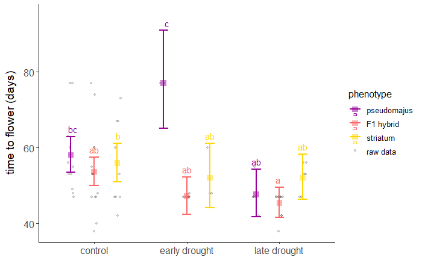

```r
tflow_raw <- ggplot(Dataset, aes(x = trt, y = days_1flower, group = colors)) +
  geom_jitter(
    aes(color = "black", fill = "black"),
    position = position_jitterdodge(0.08),
    size = 1.2,
    alpha = alpha_raw_points
  ) +
  scale_fill_manual(values=c("black", "black", "black"))+
  scale_color_manual(values=c("black", "black", "black"))+
  theme_classic() +
  my_theme





# Overlay emmeans and CI on the raw data plot
tflow_overlay_plot <- tflow_raw +
  geom_errorbar(
    data = back.emmeans_tflow,
    aes(x = trt, y = response, ymin = asymp.LCL, ymax = asymp.UCL, color = colors),
    position = position_dodge(width = 0.75),
    width = 0.3,
    size = 1
  ) +

  geom_point(
    data = back.emmeans_tflow,
    aes(x = trt, y = response, color = colors),
    position = position_dodge(width = 0.75),
    size = 3,
    alpha = 0.5,
    shape = 15

  )  +
  geom_text(
    data = back.emmeans_tflow,
    aes(
      x = trt, # Adjust position based on factor levels,
      color = colors,
      y = asymp.UCL + 0.1,  # Adjust the position of the letters
      label = .group  # Use the .group column for labels
    ),
    position = position_dodge(width = 0.75),
    vjust = -0.5,  # Adjust vertical position
    size = 4
  ) +
    scale_fill_manual(values=c("#990099", "#FF6666", "gold"))+
  scale_color_manual(values=c("#990099", "#FF6666", "gold","black"),labels = c("pseudomajus", "F1 hybrid", "striatum", "raw data"))+
  theme_classic()+
  my_theme+
guides(fill = FALSE)+
labs(color = "phenotype")+
  ylim(38,95)+
  xlab(NULL)+
  ylab("time to flower (days)")+
  theme(axis.title.y = element_text(margin = margin(r = 10)))
tflow_overlay_plot
```

# Fig 1

```r
arranged_flowering_coltrt <- ggarrange(

  flow_overlay_plot2 + ylab(NULL), flow_overlay_plot3 + ylab(NULL),

  ncol = 2,
  nrow = 1,

  labels = c("C", "D")
)


arranged_nflow_coltrt <- ggarrange(

  nflow_overlay_plot2 + ylab(NULL) + ylim(0,1.8), nflow_overlay_plot3 + ylab(NULL) +ylim(0,6.5),

  ncol = 2,
  nrow = 1,

  labels = c("F", "G")
)





# Define spacer for empty cells
white_spacer <- ggplot() + theme_void() + theme(plot.background = element_rect(fill = "white", color = NA))

# Rebuild the layout
figure1 <- ggarrange(

  # First row: survival plot on left, empty on right
  surv_overlay_plot +
    theme(axis.title.y = element_text(margin = margin(r = 10))) +
    scale_x_discrete(guide = guide_axis(n.dodge = 2))+
  labs(color = "Morphotype"),
  white_spacer,

  # Second row: flowering prob plots
  flow_overlay_plot +
    ylab("flowering prob. (all plants)") +
    theme(axis.title.y = element_text(margin = margin(r = 10))) +
    scale_x_discrete(guide = guide_axis(n.dodge = 2)),
  arranged_flowering_coltrt,

  # Third row: flower count plots
  nflow_overlay_plot +
    ylab("flower count (survivors)") +
    theme(axis.title.y = element_text(margin = margin(r = 10))) +
    scale_x_discrete(guide = guide_axis(n.dodge = 2)),
  arranged_nflow_coltrt,

  # Fourth row: height plot on left, empty on right
  height_overlay_plot +
    ylab("height (cm)") +
    theme(axis.title.y = element_text(margin = margin(r = 10))) +
    scale_x_discrete(guide = guide_axis(n.dodge = 2)),
  white_spacer,

  nrow = 4,
  ncol = 2,
  common.legend = TRUE,
  labels = c("A", "", "B", "", "E", "", "H", "")
)
# Save the figure
#ggsave("../figures/figure1a_01aug.png", figure1, height = 12.5, width = 10)
```

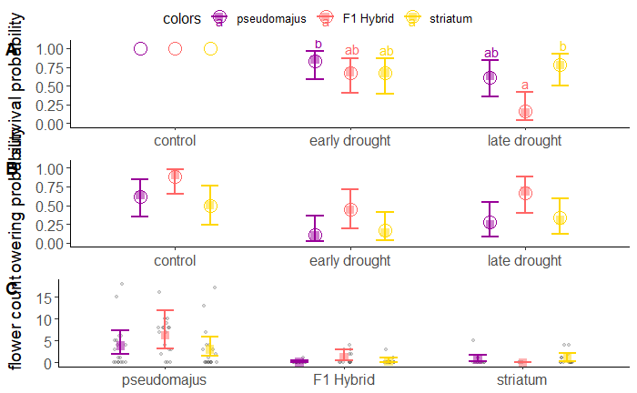

```r
figure_2_a <- ggarrange(

    surv_overlay_plot,

flow_overlay_plot,

nflow_overlay_plot,

nrow = 3,
ncol = 1,

common.legend = TRUE,

labels = c("A", "B", "C")

)
figure_2_a
```

```r
#ggsave("../figures/figure_1.png", height = 8, width = 5)
```

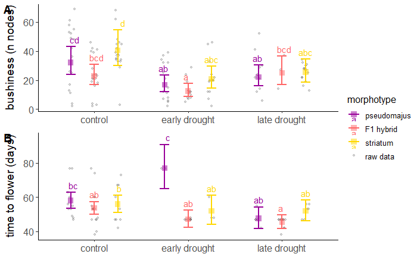

```r
# Update legend title in both plots
bushiness_overlay_plot <- bushiness_overlay_plot +
  labs(color = "morphotype", fill = "morphotype")  # depending on your legend mapping

tflow_overlay_plot <- tflow_overlay_plot +
  labs(color = "morphotype", fill = "morphotype")

# Combine with ggarrange
figure_2_b <- ggarrange(
  bushiness_overlay_plot,
  tflow_overlay_plot,
  nrow = 2,
  ncol = 1,
  common.legend = TRUE,
  legend = "right",
  labels = c("A", "B")
)
figure_2_b
```

```r
#ggsave("../figures/figure_s1a.png", height = 6.5, width = 8)
```

## save emmeans results

|  | colors | trt | estimated response | SE | df | n | lower CI | upper CI | comp | trait | CI |
| --- | --- | --- | --- | --- | --- | --- | --- | --- | --- | --- | --- |
| 1 | M_M | early drought | 0.85 | 0.09140747538 | Inf | 18 | 0.58 | 0.96 | b | survival | 0.58- 0.96 |
| 2 | M_Y | early drought | 0.68 | 0.12746705805 | Inf | 18 | 0.40 | 0.87 | ab | survival | 0.40- 0.87 |
| 3 | Y_Y | early drought | 0.67 | 0.13208961886 | Inf | 18 | 0.39 | 0.87 | ab | survival | 0.39- 0.87 |
| 4 | M_M | late drought | 0.63 | 0.13211562736 | Inf | 18 | 0.36 | 0.84 | ab | survival | 0.36- 0.84 |
| 5 | M_Y | late drought | 0.14 | 0.09154606100 | Inf | 18 | 0.04 | 0.42 | a | survival | 0.04- 0.42 |
| 6 | Y_Y | late drought | 0.78 | 0.10953862947 | Inf | 18 | 0.50 | 0.92 | b | survival | 0.50- 0.92 |
| 7 | M_M | control | 0.63 | 0.13976926006 | Inf | 18 | 0.35 | 0.85 | ab | flowering | 0.35- 0.85 |
| 8 | M_Y | control | 0.91 | 0.07121103096 | Inf | 18 | 0.65 | 0.98 | b | flowering | 0.65- 0.98 |
| 9 | Y_Y | control | 0.50 | 0.14932005517 | Inf | 18 | 0.24 | 0.77 | ab | flowering | 0.24- 0.77 |
| 10 | M_M | early drought | 0.10 | 0.07344169928 | Inf | 18 | 0.02 | 0.36 | a | flowering | 0.02- 0.36 |

[output cut: 41 more lines]

## summaries

time to flower drought-control

```r
# Filter for time to flower and extract estimates by treatment and color
df_flowering_time <- df_anovas_clean %>%
  filter(trait == "time to flower (days)")

# Compute average time to flower across morphotypes per treatment
avg_time_by_trt <- df_flowering_time %>%
  group_by(trt) %>%
  summarise(mean_time = mean(`estimated response`))

# View raw differences in days compared to control
control_time <- avg_time_by_trt %>% filter(trt == "control") %>% pull(mean_time)

avg_time_by_trt <- avg_time_by_trt %>%
  mutate(diff_vs_control = mean_time - control_time)

avg_time_by_trt
```

| trt | mean_time | diff_vs_control |
| --- | --- | --- |
| early drought | 58.70667 | 2.870000 |
| late drought | 48.34000 | -7.496667 |
| control | 55.83667 | 0.000000 |

```r
NA
```

time to flower, which was delayed by 2.9 days under early drought and accelerated by 7.5 days under late drought, relative to control conditions

n flowers

```r
library(dplyr)

# Filter the data for the "n flowers" trait
df_flowers <- df_anovas_clean %>%
  filter(trait == "n flowers") %>%
  group_by(trt) %>%
  summarise(mean_n_flowers = mean(`estimated response`))

# Calculate difference from control
df_flowers <- df_flowers %>%
  mutate(diff_vs_control = mean_n_flowers - mean_n_flowers[trt == "control"])

df_flowers
```

| trt | mean_n_flowers | diff_vs_control |
| --- | --- | --- |
| early drought | 0.5166667 | -3.800000 |
| late drought | 0.4700000 | -3.846667 |
| control | 4.3166667 | 0.000000 |

```r
NA
```

Flower production declined sharply in drought treatments, with plants producing on average 3.8 fewer flowers under early drought and 3.85 fewer under late drought compared to control conditions

survival

```r
# Calculate mean survival for early and late drought
df_survival <- df_anovas_clean %>%
  filter(trait == "survival") %>%
  group_by(trt) %>%
  summarise(
    mean_survival = mean(`estimated response`, na.rm = TRUE)
  ) %>%
  mutate(
    control_survival = 1,
    diff_vs_control = mean_survival - control_survival
  )

df_survival
```

| trt | mean_survival | control_survival | diff_vs_control |
| --- | --- | --- | --- |
| early drought | 0.7333333 | 1 | -0.2666667 |
| late drought | 0.5166667 | 1 | -0.4833333 |

```r
NA
```

Compared to the control condition (survival probability = 1.0), survival declined by 0.27 under early drought and by 0.48 under late drought

flowerin drought vs control

```r
library(dplyr)

# Filter flowering data
df_flowering <- df_anovas_clean %>%
  filter(trait == "flowering") %>%
  select(trt, estimated_response = `estimated response`)

# Calculate mean flowering probability by treatment
df_flowering_summary <- df_flowering %>%
  group_by(trt) %>%
  summarise(mean_flowering = mean(estimated_response)) %>%
  mutate(
    control_flowering = mean_flowering[trt == "control"],
    diff_vs_control = mean_flowering - control_flowering
  )

df_flowering_summary
```

| trt | mean_flowering | control_flowering | diff_vs_control |
| --- | --- | --- | --- |
| early drought | 0.2233333 | 0.68 | -0.4566667 |
| late drought | 0.4133333 | 0.68 | -0.2666667 |
| control | 0.6800000 | 0.68 | 0.0000000 |

```r
NA
NA
```

Relative to the control (0.68), flowering probability declined by 0.46 under early drought and by 0.27 under late drought

survival hybrids compared to magenta and yellow

```r
library(dplyr)

# Filter only survival trait under early drought
diff_early_MM <- df_anovas_clean %>%
  filter(trait == "survival", trt == "early drought", colors %in% c("M_M", "M_Y")) %>%
  select(colors, `estimated response`) %>%
  tidyr::pivot_wider(names_from = colors, values_from = `estimated response`) %>%
  mutate(diff_vs_MM = M_Y - M_M)

# View result
diff_early_MM
```

| M_M | M_Y | diff_vs_MM |
| --- | --- | --- |
| 0.85 | 0.68 | -0.17 |

```r
NA
NA
NA
```

```r
# Filter survival data under late drought for all morphotypes
diff_late_avg_parents <- df_anovas_clean %>%
  filter(trait == "survival", trt == "late drought", colors %in% c("M_M", "M_Y", "Y_Y")) %>%
  select(colors, `estimated response`) %>%
  pivot_wider(names_from = colors, values_from = `estimated response`) %>%
  mutate(
    avg_parents = (M_M + Y_Y) / 2,
    diff_vs_avg_parents = M_Y - avg_parents
  )

# View result
diff_late_avg_parents
```

| M_M | M_Y | Y_Y | avg_parents | diff_vs_avg_parents |
| --- | --- | --- | --- | --- |
| 0.63 | 0.14 | 0.78 | 0.705 | -0.565 |

```r
NA
```

flowering hybrids compared to magenta and yellow

```r
library(dplyr)

# Filter to flowering data
df_flowering <- df_anovas_clean %>%
  filter(trait == "flowering")

# Pivot wider to compare morphotypes side by side
df_flowering_wide <- df_flowering %>%
  select(trt, colors, `estimated response`) %>%
  tidyr::pivot_wider(names_from = colors, values_from = `estimated response`) %>%
  rename(
    early_drought = trt
  )

# Calculate absolute differences in flowering probability
df_flowering_diffs <- df_flowering_wide %>%
  mutate(
    diff_vs_MM = M_Y - M_M,
    diff_vs_YY = M_Y - Y_Y
  )

# Optional: calculate mean difference across treatments
df_flowering_summary <- df_flowering_diffs %>%
  summarise(
    mean_diff_vs_MM = mean(diff_vs_MM, na.rm = TRUE),
    mean_diff_vs_YY = mean(diff_vs_YY, na.rm = TRUE)
  )

# View results
print(df_flowering_diffs)
```

| early_drought | M_M | M_Y | Y_Y | diff_vs_MM | diff_vs_YY |
| --- | --- | --- | --- | --- | --- |
| control | 0.63 | 0.91 | 0.50 | 0.28 | 0.41 |
| early drought | 0.10 | 0.44 | 0.13 | 0.34 | 0.31 |
| late drought | 0.25 | 0.69 | 0.30 | 0.44 | 0.39 |

```r
print(df_flowering_summary)
```

| mean_diff_vs_MM | mean_diff_vs_YY |
| --- | --- |
| 0.3533333 | 0.37 |

```r
NA
```

Reduction flowering prob from control to drought

```r
library(dplyr)
library(tidyr)

# Filter for the flowering trait
df_flowering <- df_anovas_clean %>%
  filter(trait == "flowering") %>%
  select(trt, colors, `estimated response`)

# Reshape to wide format
df_flowering_wide <- df_flowering %>%
  pivot_wider(names_from = trt, values_from = `estimated response`) %>%
  rename(
    early = `early drought`,
    late = `late drought`,
    control = control
  )

# Calculate raw differences in flowering probability
df_flowering_diff <- df_flowering_wide %>%
  mutate(
    diff_early = control - early,
    diff_late = control - late
  )

# Compute average reduction across morphotypes
df_flowering_summary <- df_flowering_diff %>%
  summarise(
    mean_diff_early = mean(diff_early, na.rm = TRUE),
    mean_diff_late = mean(diff_late, na.rm = TRUE)
  )

# Output the data
print(df_flowering_diff)
```

| colors | control | early | late | diff_early | diff_late |
| --- | --- | --- | --- | --- | --- |
| M_M | 0.63 | 0.10 | 0.25 | 0.53 | 0.38 |
| M_Y | 0.91 | 0.44 | 0.69 | 0.47 | 0.22 |
| Y_Y | 0.50 | 0.13 | 0.30 | 0.37 | 0.20 |

```r
print(df_flowering_summary)
```

| mean_diff_early | mean_diff_late |
| --- | --- |
| 0.4566667 | 0.2666667 |

```r
NA
NA
NA
```

nflowers hybrids compared to parental in control and early drought

```r
library(dplyr)

# Filter only the relevant rows: trait == "n flowers" and trt in control or early drought
df_flowers <- df_anovas_clean %>%
  filter(trait == "n flowers", trt %in% c("control", "early drought")) %>%
  select(trt, colors, `estimated response`) %>%
  pivot_wider(names_from = colors, values_from = `estimated response`) %>%
  mutate(
    parental_avg = (M_M + Y_Y) / 2,
    hybrid_diff = M_Y - parental_avg
  )

# Print the result
df_flowers
```

| trt | M_M | M_Y | Y_Y | parental_avg | hybrid_diff |
| --- | --- | --- | --- | --- | --- |
| control | 3.78 | 6.17 | 3.00 | 3.39 | 2.78 |
| early drought | 0.07 | 1.17 | 0.31 | 0.19 | 0.98 |

```r
NA
```

height hybrids

```r
# Filter data for the trait "height (cm)"
df_height <- df_anovas_clean %>%
  filter(trait == "height (cm)") %>%
  select(trt, colors, `estimated response`) %>%
  rename(response = `estimated response`)

# Spread the data to wide format for comparison
df_height_wide <- df_height %>%
  tidyr::pivot_wider(names_from = colors, values_from = response) %>%
  rename(M_M = `M_M`, M_Y = `M_Y`, Y_Y = `Y_Y`)

# Compare hybrid vs parental under control
df_height_wide <- df_height_wide %>%
  mutate(
    parental_avg = (M_M + Y_Y) / 2,
    hybrid_diff_vs_parental = M_Y - parental_avg
  )

# Compute drop in height from control to each drought treatment, per morphotype
df_height_drop <- df_height_wide %>%
  arrange(match(trt, c("control", "early drought", "late drought"))) %>%
  mutate(
    drop_M_M = M_M - M_M[trt == "control"],
    drop_M_Y = M_Y - M_Y[trt == "control"],
    drop_Y_Y = Y_Y - Y_Y[trt == "control"]
  )

# Show results
df_height_drop
```

| trt | M_M | M_Y | Y_Y | parental_avg | hybrid_diff_vs_parental | drop_M_M | drop_M_Y | drop_Y_Y |
| --- | --- | --- | --- | --- | --- | --- | --- | --- |
| control | 47.00 | 67.34 | 40.64 | 43.82 | 23.52 | 0.00 | 0.00 | 0.00 |
| early drought | 15.35 | 18.68 | 21.19 | 18.27 | 0.41 | -31.65 | -48.66 | -19.45 |
| late drought | 25.68 | 22.49 | 28.54 | 27.11 | -4.62 | -21.32 | -44.85 | -12.10 |

```r
# Filter for "height (cm)" under control conditions
df_control_height <- df_anovas_clean %>%
  filter(trait == "height (cm)", trt == "control") %>%
  select(colors, `estimated response`) %>%
  rename(height = `estimated response`)

# Extract height values
height_MM <- df_control_height %>% filter(colors == "M_M") %>% pull(height)
height_MY <- df_control_height %>% filter(colors == "M_Y") %>% pull(height)
height_YY <- df_control_height %>% filter(colors == "Y_Y") %>% pull(height)

# Calculate differences
diff_vs_MM <- height_MY - height_MM
diff_vs_YY <- height_MY - height_YY
diff_vs_avg_parental <- height_MY - mean(c(height_MM, height_YY))

# Print results
cat("Hybrids were", round(diff_vs_MM, 2), "cm taller than M_M\n")
```

```
Hybrids were 20.34 cm taller than M_M
```

```r
cat("Hybrids were", round(diff_vs_YY, 2), "cm taller than Y_Y\n")
```

```
Hybrids were 26.7 cm taller than Y_Y
```

```r
cat("Hybrids were", round(diff_vs_avg_parental, 2), "cm taller than the average of both parentals\n")
```

```
Hybrids were 23.52 cm taller than the average of both parentals
```

flowering time magentas

```r
library(dplyr)
library(tidyr)

# Subset to magenta morphotype and time to flower
df_mm <- df_anovas_clean %>%
  filter(colors == "M_M", trait == "time to flower (days)") %>%
  select(trt, estimated_response = `estimated response`)

# Pivot to wide format by treatment
df_mm_wide <- df_mm %>%
  pivot_wider(names_from = trt, values_from = estimated_response)

# Calculate difference in days: early drought - control
diff_early_vs_control <- df_mm_wide$`early drought` - df_mm_wide$control

# Print the result
diff_early_vs_control
```

```
[1] 19
```

| trait | early drought | late drought | control | early_drought_pct_decrease | late_drought_pct_decrease |
| --- | --- | --- | --- | --- | --- |
| bushiness (n nodes) | 16.6300000 | 24.2000000 | 31.806667 | 47.7 | 23.9 |
| flowering | 0.2233333 | 0.4133333 | 0.680000 | 67.2 | 39.2 |
| height (cm) | 18.4066667 | 25.5700000 | 51.660000 | 64.4 | 50.5 |
| n flowers | 0.5166667 | 0.4700000 | 4.316667 | 88.0 | 89.1 |
| survival | 0.7333333 | 0.5166667 | 1.000000 | 26.7 | 48.3 |
| time to flower (days) | 58.7066667 | 48.3400000 | 55.836667 | -5.1 | 13.4 |

```r
# All traits included now
overall_summary <- df_effects %>%
  summarise(
    mean_early = round(mean(early_drought_pct_decrease, na.rm = TRUE), 1),
    min_early  = round(min(early_drought_pct_decrease, na.rm = TRUE), 1),
    max_early  = round(max(early_drought_pct_decrease, na.rm = TRUE), 1),
    mean_late  = round(mean(late_drought_pct_decrease, na.rm = TRUE), 1),
    min_late   = round(min(late_drought_pct_decrease, na.rm = TRUE), 1),
    max_late   = round(max(late_drought_pct_decrease, na.rm = TRUE), 1)
  )

print(overall_summary)
```

| mean_early | min_early | max_early | mean_late | min_late | max_late |
| --- | --- | --- | --- | --- | --- |
| 48.1 | -5.1 | 88 | 44.1 | 13.4 | 89.1 |

```r
NA
```

Drought treatments affected all measured phenotypic traits, with an average reduction of 48.1% under early drought (range: –5.1% to 88.0%) and 44.1% under late drought (range: 13.4% to 89.1%; Table 1, S3, S4; Figure 2, S2).

## % difference in flowering

```r
# Filter to flowering trait only
df_flowering <- df_anovas_clean %>%
  filter(trait == "flowering")

# Reshape the data to have one row per (treatment, morphotype) pair
df_wide <- df_flowering %>%
  select(trt, colors, flowering_prob = `estimated.response`) %>%
  filter(colors %in% c("M_M", "M_Y", "Y_Y")) %>%
  tidyr::pivot_wider(names_from = colors, values_from = flowering_prob)

# Calculate percent increase of hybrid compared to each parental morph
df_wide <- df_wide %>%
  mutate(
    pct_increase_vs_MM = ((M_Y - M_M) / M_M) * 100,
    pct_increase_vs_YY = ((M_Y - Y_Y) / Y_Y) * 100
  )

# View results
print(df_wide)
```

| trt | M_M | M_Y | Y_Y | pct_increase_vs_MM | pct_increase_vs_YY |
| --- | --- | --- | --- | --- | --- |
| control | 0.63 | 0.91 | 0.50 | 44.44444 | 82.0000 |
| early drought | 0.10 | 0.44 | 0.13 | 340.00000 | 238.4615 |
| late drought | 0.25 | 0.69 | 0.30 | 176.00000 | 130.0000 |